# Stock Returns Prediction using Kernel Adaptive Filtering within a Stock Market Interdependence Approach

This work uses a two-stage approach, using kernel adaptive filtering within a stock market interdependence approach to sequentially predict stock returns. The proposed framework has been tested on 24 different stocks from major economies.

## Contents

**1. Experimental Desing**

```
1.1. Performance measures

1.2. Baseline methods

1.3. Dataset
```

**2. Results and Analysis**

```
2.1. Mean Absolute Error (MAE)

2.2. Mean Squared Error (MSE)

2.3. Sharpe Ratio (SR)

2.4. Which models are more "important"
```

**3. Conclussion**

## Links of Interest

- [GitHub Repository](https://github.com/segarciave/ESwA-2020)
- Data
- Results

## 1. Experimental Desing

The aim is to use the last ten stock returns to predict the current day price change.

### 1.1. Performance measures

The proposed framework for stock returns prediction is validated with the following performance measures:

- Mean Absolute Error (MAE)
- Mean Squared Error (MSE)
- Sharpe Ratio (SR)

### 1.2. Baseline methods

For comparison purposes, the proposed framework is contrasted with the following online prediction methods:

- Long Short-Term Memory (LSTM)
- Nearest Instance Centroid-Estimation (NICE)
- Quantized Kernel Least-Mean-Square (QKLMS)
- Vector Autoregression (VAR)
- Vector Error Correction Model (VECM)

### 1.3. Dataset

The daily closing prices data used to calculate the returns are collected from [Yahoo Finance](https://finance.yahoo.com/). Here, the daily log returns are calculated using the adjusted closing prices of each day. The considered training set ranges from 2006 to 2016, while the test set covers 2017 to 2018. The dataset, which is publicly available, can be downloaded for free using the **`yfinance`** Python library as follows:

```python
import yfinance as yf
import numpy as np

start  = '2006-01-13'
end    = '2018-03-27'
ticker = list(['DE_ADS', 'DE_ALV', 'DE_DPW', 'DE_DTE', 'DE_HEI', 'DE_LIN', 'DE_MRK', 'DE_SAP',
               'UK_ADM', 'UK_AHT', 'UK_BA', 'UK_BP', 'UK_CCL', 'UK_IAG', 'UK_SKY', 'UK_VOD',
               'US_AAL', 'US_AAPL', 'US_AMZN', 'US_C', 'US_GOOGL', 'US_MSFT', 'US_SPY', 'US_T'])
count = 1
for tic in ticker:
    print('Stock ' + str(count) + '/' + '24' + ': ' + tic[3:])
    symbol = tic[3:]
    df     = yf.download(symbol, start, end)
    col    = list(df.columns.values)

    stock                    = df[[col[0], col[1], col[2], col[3], col[4]]]
    stock['Log Return']      = np.log(stock[col[4]]) - np.log(stock[col[4]].shift(1))
    stock['Log Return Stan'] = (stock['Log Return'][1:] - np.mean(stock['Log Return'][1:])/np.std(stock['Log Return'][1:]))

    count = count + 1

    #stock.to_csv('CSV\\' + tic[:2] + '_' + symbol + '.csv')
```

```
Stock 1/24: ADS
[*********************100%***********************]  1 of 1 completed
Stock 2/24: ALV
[*********************100%***********************]  1 of 1 completed
Stock 3/24: DPW
[*********************100%***********************]  1 of 1 completed
Stock 4/24: DTE
[*********************100%***********************]  1 of 1 completed
Stock 5/24: HEI
[*********************100%***********************]  1 of 1 completed
Stock 6/24: LIN
[*********************100%***********************]  1 of 1 completed
Stock 7/24: MRK
[*********************100%***********************]  1 of 1 completed
Stock 8/24: SAP
[*********************100%***********************]  1 of 1 completed
Stock 9/24: ADM
[*********************100%***********************]  1 of 1 completed
Stock 10/24: AHT
[*********************100%***********************]  1 of 1 completed
Stock 11/24: BA
[*********************100%***********************]  1 of 1 completed
Stock 12/24: BP
[*********************100%***********************]  1 of 1 completed
Stock 13/24: CCL
[*********************100%***********************]  1 of 1 completed
Stock 14/24: IAG
[*********************100%***********************]  1 of 1 completed
Stock 15/24: SKY
[*********************100%***********************]  1 of 1 completed
Stock 16/24: VOD
[*********************100%***********************]  1 of 1 completed
Stock 17/24: AAL
[*********************100%***********************]  1 of 1 completed
Stock 18/24: AAPL
[*********************100%***********************]  1 of 1 completed
Stock 19/24: AMZN
[*********************100%***********************]  1 of 1 completed
Stock 20/24: C
[*********************100%***********************]  1 of 1 completed
Stock 21/24: GOOGL
[*********************100%***********************]  1 of 1 completed
Stock 22/24: MSFT
[*********************100%***********************]  1 of 1 completed
Stock 23/24: SPY
[*********************100%***********************]  1 of 1 completed
Stock 24/24: T
[*********************100%***********************]  1 of 1 completed
```

**Note:** The previous code allows you to download the closing prices of each stock from `Yahoo Finance`. You can uncomment the last line to save the stock returns as `CSV` files. Then, for coding purposes, these `CSV` files are transformed into **`pickle`** files, which are available [**here**](https://github.com/segarciave/ESwA-2020/tree/master/Data). In the simulations, as suggested by previous studies, the dataset is standardized so all stocks have a mean estimation of zero and a standard deviation of one.

## 2. Results and Analysis

The **`Python`** codes can be download from the following [GitHub repository](https://github.com/segarciave/ESwA-2020), where each **`pickle`** file is loaded into the tested methods. The **results** are also stored in **`pickle`** files and are available [**here**](https://github.com/segarciave/ESwA-2020/tree/master/Results). The following code collect all the results to compute Mean Absolute Error (MAE) and Sharpe Ratio (SR).

```python
#==============================================================================
#                               Importing Libraries
#==============================================================================
import os
import pickle
import numpy as np
import pandas as pd
from os import listdir
import sklearn.metrics as metrics


#==============================================================================
#                                Importing Files
#==============================================================================
cwd      = os.getcwd()
data_dir = os.path.join(cwd,'Results\\')

Stocks = {}

for file_name in listdir(data_dir):
    path         = os.path.join(data_dir,file_name)
    file         = file_name.split('.')[0]
    Stocks[file] = pickle.load(open('Results\\' + file + '.pkl', 'rb'))

    desired    = Stocks[file]['Figure 1']['Desired']
    prediction = Stocks[file]['Figure 1']['Prediction']

    #Computing Sharpe Ratio
    daily_ret = (Stocks[file]['Figure 1']['Prediction'][1:] - Stocks[file]['Figure 1']['Prediction'][:-1])/(Stocks[file]['Figure 1']['Prediction'][:-1])
    avg_daily_return = np.mean(daily_ret)
    volatility       = np.std(daily_ret)
    Stocks[file]['Table 1']['Sharpe'] = np.sqrt(252)*(avg_daily_return/volatility)

    #Computing Mean Absolute Error (MAE)
    Stocks[file]['Table 1']['MAE'] = metrics.mean_absolute_error(desired, prediction)
```

**Note:** Please extract the files of each **`WinRAR`** folder (LSTM, NICE, etc) and put them together in a **single** folder called **`Results`**. This will allow you to run the previous code successfully.

Then, for visualization purposes, we create a single dataframe as follows:

```python
#==============================================================================
#                                Single Dataframe
#==============================================================================
keys_stck = list(Stocks.keys())

mse    = np.zeros([144])
sharpe = np.zeros([144])
mae    = np.zeros([144])

for i in range(len(keys_stck)):
    mse[i]    = Stocks[keys_stck[i]]['Table 1']['MSE']
    sharpe[i] = Stocks[keys_stck[i]]['Table 1']['Sharpe']
    mae[i]    = Stocks[keys_stck[i]]['Table 1']['MAE']

mse          = np.around(np.transpose(mse.reshape(6,24)), decimals=4)
mse_mean     = np.around(np.mean(mse, 0)[np.newaxis, :], decimals=3)
mse_std      = np.around(np.std(mse, 0)[np.newaxis, :], decimals=3)
table_mse    = pd.DataFrame(mse_mean, columns=['LSTM', 'NICE', 'Proposal', 'QKLMS', 'VAR', 'VECM'])

sharpe       = np.around(np.transpose(sharpe.reshape(6,24)), decimals=4)
sharpe_mean  = np.around(np.mean(sharpe, 0)[np.newaxis, :], decimals=3)
sharpe_std   = np.around(np.std(sharpe, 0)[np.newaxis, :], decimals=3)
table_sharpe = pd.DataFrame(sharpe_mean, columns=['LSTM', 'NICE', 'Proposal', 'QKLMS', 'VAR', 'VECM'])

mae          = np.around(np.transpose(mae.reshape(6,24)), decimals=4)
mae_mean     = np.around(np.mean(mae, 0)[np.newaxis, :],  decimals=3)
mae_std      = np.around(np.std(mae, 0)[np.newaxis, :],  decimals=3)
table_mae    = pd.DataFrame(mae_mean, columns=['LSTM', 'NICE', 'Proposal', 'QKLMS', 'VAR', 'VECM'])
```

### 2.1. Mean Absolute Error (MAE)

The following code shows the MAE values of each method in the considered stocks. Although LSTM shows the best performance, the compared methods also converge to relatively low values of MAE. However, note that this scale-dependent metric may be unable to quantify the prediction of abrupt changes in stock returns.

```python
MAE = pd.DataFrame(data    = mae,
                   index   = ['ADS', 'ALV', 'DPW', 'DTE', 'HEI', 'LIN', 'MRK', 'SAP',
                              'ADM', 'AHT', 'BA', 'BP', 'CCL', 'IAG', 'SKY', 'VOD',
                              'AAL', 'AAPL', 'AMZN', 'C', 'GOOGL', 'MSFT', 'SPY', 'T'],
                   columns = ['LSTM', 'NICE', 'Proposal', 'QKLMS', 'VAR', 'VECM'])

print(MAE)
```

```
         LSTM    NICE  Proposal   QKLMS     VAR    VECM
ADS    0.0109  0.0109    0.0137  0.0109  0.0115  0.0136
ALV    0.0100  0.0101    0.0122  0.0100  0.0101  0.0122
DPW    0.0611  0.0608    0.0645  0.0609  0.0601  0.0711
DTE    0.0063  0.0063    0.0142  0.0063  0.0065  0.0073
HEI    0.0099  0.0097    0.0161  0.0098  0.0102  0.0115
LIN    0.0077  0.0075    0.0100  0.0075  0.0077  0.0093
MRK    0.0071  0.0071    0.0112  0.0071  0.0073  0.0087
SAP    0.0070  0.0078    0.0130  0.0078  0.0072  0.0086
ADM    0.0084  0.0083    0.0154  0.0083  0.0087  0.0105
AHT    0.0153  0.0153    0.0215  0.0152  0.0162  0.0196
BA     0.0089  0.0087    0.0134  0.0088  0.0093  0.0106
BP     0.0076  0.0077    0.0194  0.0077  0.0076  0.0090
CCL    0.0081  0.0082    0.0156  0.0082  0.0085  0.0106
IAG    0.0210  0.0213    0.0322  0.0212  0.0214  0.0246
SKY    0.0323  0.0323    0.0390  0.0322  0.0325  0.0398
VOD    0.0072  0.0083    0.0166  0.0081  0.0074  0.0088
AAL    0.0139  0.0149    0.0228  0.0148  0.0155  0.0181
AAPL   0.0086  0.0086    0.0224  0.0085  0.0088  0.0095
AMZN   0.0095  0.0102    0.0232  0.0100  0.0101  0.0115
C      0.0087  0.0094    0.0417  0.0094  0.0097  0.0123
GOOGL  0.0080  0.0082    0.0098  0.0081  0.0082  0.0091
MSFT   0.0077  0.0074    0.0100  0.0075  0.0078  0.0090
SPY    0.0039  0.0038    0.0057  0.0038  0.0041  0.0050
T      0.0083  0.0081    0.0105  0.0082  0.0081  0.0096
```

### 2.2. Mean Squared Error (MSE)

The following table summarizes the MSE prediction performance, where lower values are better. The compared methods show similar MSE values, suggesting a relatively good prediction performance on all considered stocks under this metric. The proposed interdependence strategy allows predicting each stock using not only the local model but also the models learned from other stock markets, supporting the learning of arbitrary long-term dependencies in the input sequences.

```python
MSE = pd.DataFrame(data    = mse,
                   index   = ['ADS', 'ALV', 'DPW', 'DTE', 'HEI', 'LIN', 'MRK', 'SAP',
                              'ADM', 'AHT', 'BA', 'BP', 'CCL', 'IAG', 'SKY', 'VOD',
                              'AAL', 'AAPL', 'AMZN', 'C', 'GOOGL', 'MSFT', 'SPY', 'T'],
                   columns = ['LSTM', 'NICE', 'Proposal', 'QKLMS', 'VAR', 'VECM'])

print(MSE)
```

```
         LSTM    NICE  Proposal   QKLMS     VAR    VECM
ADS    0.0003  0.0003    0.0004  0.0003  0.0003  0.0004
ALV    0.0003  0.0003    0.0003  0.0003  0.0003  0.0003
DPW    0.0135  0.0135    0.0140  0.0134  0.0132  0.0172
DTE    0.0001  0.0001    0.0003  0.0001  0.0001  0.0001
HEI    0.0002  0.0002    0.0004  0.0002  0.0002  0.0002
LIN    0.0001  0.0001    0.0002  0.0001  0.0001  0.0001
MRK    0.0001  0.0001    0.0002  0.0001  0.0001  0.0002
SAP    0.0001  0.0001    0.0003  0.0001  0.0001  0.0001
ADM    0.0002  0.0002    0.0004  0.0002  0.0002  0.0002
AHT    0.0005  0.0005    0.0008  0.0005  0.0005  0.0007
BA     0.0002  0.0002    0.0003  0.0002  0.0002  0.0002
BP     0.0001  0.0001    0.0005  0.0001  0.0001  0.0001
CCL    0.0001  0.0001    0.0004  0.0001  0.0001  0.0002
IAG    0.0009  0.0009    0.0016  0.0009  0.0009  0.0011
SKY    0.0028  0.0028    0.0034  0.0028  0.0028  0.0037
VOD    0.0001  0.0001    0.0004  0.0001  0.0001  0.0002
AAL    0.0004  0.0004    0.0008  0.0004  0.0004  0.0005
AAPL   0.0001  0.0002    0.0006  0.0002  0.0002  0.0002
AMZN   0.0002  0.0002    0.0007  0.0002  0.0002  0.0003
C      0.0001  0.0002    0.0019  0.0002  0.0002  0.0002
GOOGL  0.0001  0.0001    0.0002  0.0001  0.0001  0.0002
MSFT   0.0001  0.0001    0.0002  0.0001  0.0001  0.0002
SPY    0.0000  0.0000    0.0001  0.0000  0.0000  0.0001
T      0.0001  0.0001    0.0002  0.0001  0.0001  0.0002
```

### 2.3. Sharpe Ratio (SR)

```python
SR = pd.DataFrame(data     = sharpe,
                   index   = ['ADS', 'ALV', 'DPW', 'DTE', 'HEI', 'LIN', 'MRK', 'SAP',
                              'ADM', 'AHT', 'BA', 'BP', 'CCL', 'IAG', 'SKY', 'VOD',
                              'AAL', 'AAPL', 'AMZN', 'C', 'GOOGL', 'MSFT', 'SPY', 'T'],
                   columns = ['LSTM', 'NICE', 'Proposal', 'QKLMS', 'VAR', 'VECM'])

print(SR)
```

```
         LSTM    NICE  Proposal   QKLMS     VAR    VECM
ADS    0.9017  0.2162    3.6583  0.0051  2.2682  0.9369
ALV    1.2965  0.2089    3.3982  0.0729  1.0817  0.0021
DPW   -0.7522 -1.0027    2.1300 -1.1187 -0.8717  0.7948
DTE    0.2688 -0.0372    1.9498 -0.1236  0.7665  1.2571
HEI    0.8574  0.2089    2.0087 -0.0287  1.3908  2.0077
LIN    0.5044  0.1126    3.1285  0.0646  1.2623  2.5074
MRK    0.7296  0.0983    3.6270 -0.0257  1.4655  0.6756
SAP    0.4705  0.0497    4.3900 -0.0371  1.8604  2.4806
ADM    0.4663  0.3340    5.9617  0.0065  2.4326  1.0164
AHT    2.2794  0.9360    5.3711 -1.2048 -1.3246 -0.3778
BA     0.7246  0.0998    2.1991 -0.0579  1.2097  1.2656
BP     1.0361  1.5645    6.5490  0.1094 -0.0275 -1.3034
CCL    1.2433  0.5456    5.9871  0.0216 -0.7435 -0.5154
IAG    1.9193 -1.1230    4.5652  1.5662  0.3662 -1.3497
SKY   -0.2469  0.3637    1.4274  0.3180 -1.2898 -1.3334
VOD    0.6955  0.2220    5.2585  0.1688  0.3891  1.4227
AAL    1.1319 -0.5774    5.8926  0.4946 -1.1440 -1.1616
AAPL   0.6432  0.1279    2.6692 -0.1274  1.0422  1.6480
AMZN   0.5934  0.1681    1.5527 -0.0205  1.0327  1.7307
C      0.9750  0.2737    3.6621  0.0879  1.1656 -0.3031
GOOGL  0.5118  0.1185    2.9763  0.0459  1.3334  1.2835
MSFT   0.5291  0.1301    2.8933  0.0355  1.2268  2.1107
SPY    0.4121  0.0827    1.7878 -0.0977  1.0711  1.7259
T      1.2947  0.1438    3.3456 -0.0684  1.3681  1.1828
```

### 2.4. Which models are more "important"?

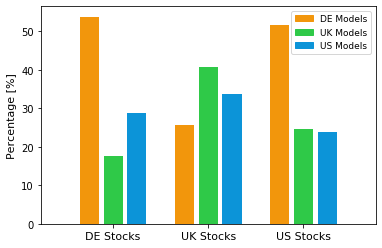

```python
#==============================================================================
#                              Histogram: Markets
#==============================================================================

import os
import pickle
import numpy as np
from os import listdir
from collections import Counter
import matplotlib.pyplot as plt
import matplotlib.patches as mpatches



crr_wd         = os.getcwd()
data_dir_trte  = os.path.join(crr_wd,'Labels_DE')
Labels = {}
for trte_stock in listdir(data_dir_trte):
    key_df = trte_stock.split('.')[0].split('Proposal_')[1]
    Labels[key_df] = pickle.load(open('Labels_DE\\' + str(trte_stock), 'rb'))
keys_stocks = list(Labels.keys())
Lab_Mark    = []
for tick in keys_stocks:
    Lab_Mark = np.append(Lab_Mark, Labels[tick]['Figure 1']['Labels_Market'])
frequency = Counter(Lab_Mark)
DE_DE = (frequency[1]/len(Lab_Mark))*100
UK_DE = (frequency[2]/len(Lab_Mark))*100
US_DE = (frequency[3]/len(Lab_Mark))*100


crr_wd         = os.getcwd()
data_dir_trte  = os.path.join(crr_wd,'Labels_UK')
Labels = {}
for trte_stock in listdir(data_dir_trte):
    key_df = trte_stock.split('.')[0].split('Proposal_')[1]
    Labels[key_df] = pickle.load(open('Labels_UK\\' + str(trte_stock), 'rb'))
keys_stocks = list(Labels.keys())
Lab_Mark    = []
for tick in keys_stocks:
    Lab_Mark = np.append(Lab_Mark, Labels[tick]['Figure 1']['Labels_Market'])
frequency = Counter(Lab_Mark)
DE_UK = (frequency[1]/len(Lab_Mark))*100
UK_UK = (frequency[2]/len(Lab_Mark))*100
US_UK = (frequency[3]/len(Lab_Mark))*100


crr_wd         = os.getcwd()
data_dir_trte  = os.path.join(crr_wd,'Labels_US')
Labels = {}
for trte_stock in listdir(data_dir_trte):
    key_df = trte_stock.split('.')[0].split('Proposal_')[1]
    Labels[key_df] = pickle.load(open('Labels_US\\' + str(trte_stock), 'rb'))
keys_stocks = list(Labels.keys())
Lab_Mark    = []
for tick in keys_stocks:
    Lab_Mark = np.append(Lab_Mark, Labels[tick]['Figure 1']['Labels_Market'])
frequency = Counter(Lab_Mark)
DE_US = (frequency[1]/len(Lab_Mark))*100
UK_US = (frequency[2]/len(Lab_Mark))*100
US_US = (frequency[3]/len(Lab_Mark))*100


plt.figure()
plt.bar(list([1,2,3,4,5,
              6,7,8,9,
              10,11,12,13]),
    np.array([0, DE_DE, UK_DE, US_DE, 0,
              DE_UK, UK_UK, US_UK, 0,
              DE_US, UK_US, US_US, 0]),
    color=['#F2960C','#F2960C', '#2FC948', '#0C94D8', '#0C94D8',
           '#F2960C', '#2FC948', '#0C94D8', '#0C94D8',
           '#F2960C', '#2FC948', '#0C94D8', '#0C94D8'])
plt.ylabel('Percentage [%]', size=11)
plt.xticks(np.array([[3], [7], [11]]), ('DE Stocks', 'UK Stocks', 'US Stocks'), size=11)



DE_leg = mpatches.Patch(color='#F2960C', label='DE Models')
UK_leg = mpatches.Patch(color='#2FC948', label='UK Models')
US_leg = mpatches.Patch(color='#0C94D8', label='US Models')

plt.legend(handles=[DE_leg,UK_leg,US_leg], prop={'size': 9})

fig = plt.gcf()
```

The next figure shows that there are some stocks with **`0%`** such as **`ADS`**, **`DTE`**, **`LIN`**, **`SKY`**, **`AAL`**, etc. This means that their models were **not** used to obtain their own predictions, **nor** were they used to predict other stocks. However, as seen from previous tables, their performance is still competitive.

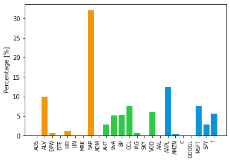

```python
#==============================================================================
#                             Histogram: Stocks
#==============================================================================
import os
import pickle
import numpy as np
from os import listdir
import matplotlib.pyplot as plt
from collections import Counter

crr_wd = os.getcwd()
data_dir_trte  = os.path.join(crr_wd,'Labels_ALL')

Labels = {}
for trte_stock in listdir(data_dir_trte):
    key_df = trte_stock.split('.')[0].split('Proposal_')[1]
    Labels[key_df] = pickle.load(open('Labels_ALL\\' + str(trte_stock), 'rb'))


keys_stocks = list(Labels.keys())
Lab_Stock   = []
for tick in keys_stocks:
     Lab_Stock = Lab_Stock + list(Labels[tick]['Table 1']['Labs_Dicti_Ticks'].values())


frequency = Counter(Lab_Stock)
ADS       = (frequency['DE_ADS']/len(Lab_Stock))*100
ALV       = (frequency['DE_ALV']/len(Lab_Stock))*100
DPW       = (frequency['DE_DPW']/len(Lab_Stock))*100
DTE       = (frequency['DE_DTE']/len(Lab_Stock))*100
HEI       = (frequency['DE_HEI']/len(Lab_Stock))*100
LIN       = (frequency['DE_LIN']/len(Lab_Stock))*100
MRK       = (frequency['DE_MRK']/len(Lab_Stock))*100
SAP       = (frequency['DE_SAP']/len(Lab_Stock))*100

ADM       = (frequency['UK_ADM']/len(Lab_Stock))*100
AHT       = (frequency['UK_AHT']/len(Lab_Stock))*100
BA        = (frequency['UK_BA']/len(Lab_Stock))*100
BP        = (frequency['UK_BP']/len(Lab_Stock))*100
CCL       = (frequency['UK_CCL']/len(Lab_Stock))*100
IAG       = (frequency['UK_IAG']/len(Lab_Stock))*100
SKY       = (frequency['UK_SKY']/len(Lab_Stock))*100
VOD       = (frequency['UK_VOD']/len(Lab_Stock))*100

AAL       = (frequency['US_AAL']/len(Lab_Stock))*100
AAPL      = (frequency['US_AAPL']/len(Lab_Stock))*100
AMZN      = (frequency['US_AMZN']/len(Lab_Stock))*100
C         = (frequency['US_C']/len(Lab_Stock))*100
GOOGL     = (frequency['US_GOOGL']/len(Lab_Stock))*100
MSFT      = (frequency['US_MSFT']/len(Lab_Stock))*100
SPY       = (frequency['US_SPY']/len(Lab_Stock))*100
T         = (frequency['US_T']/len(Lab_Stock))*100



plt.figure()
plt.bar(list([1,2,3,4,5,6,7,8,
              9,10,11,12,13,14,15,16,
              17,18,19,20,21,22,23,24]),
    np.array([ADS, ALV, DPW, DTE, HEI, LIN, MRK, SAP,
              ADM, AHT, BA, BP, CCL, IAG, SKY, VOD,
              AAL, AAPL, AMZN, C, GOOGL, MSFT, SPY, T]),
    color=['#F2960C','#F2960C','#F2960C','#F2960C','#F2960C','#F2960C','#F2960C','#F2960C',
           '#2FC948','#2FC948','#2FC948','#2FC948','#2FC948','#2FC948','#2FC948','#2FC948',
           '#0C94D8','#0C94D8','#0C94D8','#0C94D8','#0C94D8','#0C94D8','#0C94D8','#0C94D8'])
plt.ylabel('Percentage [%]', size=10)
plt.xticks(np.array([[1], [2], [3], [4], [5], [6], [7], [8],
                     [9], [10], [11], [12], [13], [14], [15], [16],
                     [17], [18], [19], [20], [21], [22], [23], [24]]),
    ('ADS', 'ALV', 'DPW', 'DTE', 'HEI', 'LIN', 'MRK', 'SAP',
     'ADM', 'AHT', 'BvA', 'BP', 'CCL', 'IAG', 'SKY', 'VOD',
     'AAL', 'AAPL', 'AMZN', 'C', 'GOOGL', 'MSFT', 'SPY', 'T'), size=8, rotation='vertical')

fig = plt.gcf()
```

## 3. Conclussion

This study introduces a framework for stock returns prediction using KAF within a stock market interdependence approach. The framework sequentially predicts stock returns by considering interconnections between stock markets. The proposed sequential learning strategy uses the data distribution as the criterion to encode different patterns of the input space, which in some circumstances may yield a more compact network. This strategy helps maximize returns and reduces volatility while maintaining the robustness and simplicity of kernel-based adaptive filters. In addition, as the simulation results show, the models learned from the German market are more suitable for making predictions in other stock markets. This suggests that the US market is more influenced by the European and not vice versa, which is in line with previous empirical findings.